# CHronoZ | Lead-lag correlation

## Summary

The saved run evaluates **8,775 pair/lag combinations** across **351 pairs**, using calendar shifts from **-12 to +12 months**. **194 pairs** have their largest absolute Pearson correlation at zero lag; **157 pairs** peak at a nonzero lag. Every evaluated lag has at least 60 paired observations. These in-sample maxima are not predictive validation.

Charts and tables use full dataset titles. Missing months remain missing. This summary describes the saved run; the final summary cell recomputes the results when inputs or parameters change.

## Context & Methods

How does pairwise association change when one monthly change series is shifted relative to another?

### Assumptions and scope

- Native monthly series only, selected by both expected and inferred frequency. Weekly and quarterly exclusions are displayed.
- Use the same explicit percentage-change / first-difference registry as the initial correlation notebook. Rates use percentage-point changes; hours use hour changes.
- Changes require consecutive calendar months. Dropped observations remain gaps; a September-November move is never treated as one month.
- No re-cleaning, interpolation, filling, frequency conversion, model training, or automatic variable removal.
- Correlation is descriptive co-movement. It does not establish causality or predictive value. No release-calendar/vintage data is available, so observation dates are not information-availability dates.
- Define lag k as corr(X at t, Y at t+k). Positive k means the first variable precedes the second by k calendar months; negative k reverses that ordering.
- Scan -12 to +12 calendar months using >=60 pairs per lag. Select the largest absolute Pearson value per unique pair; ties favor the smallest absolute lag.
- Peak selection searches many comparisons and can overstate apparent strength. Different lag profiles can use different samples. Results are exploratory, not significance tests or out-of-sample forecasts.

**Inputs:** `data/cleaned/series_metadata.csv`, the referenced cleaned series, and `data/audit/data_cleaning_audit.csv`. All inputs are read directly; this notebook does not depend on another notebook being run. **Outputs:** `outputs/lead_lag/`. Full titles are used in reports; source IDs remain internal. **Environment:** Python with `requirements-notebook.txt`; Restart Kernel and Run All from the project or notebook folder.

### Setup and editable parameters

```
Inputs: C:\Users\HYPE AMD\Desktop\CHronoZ-Economic-Modelling\data\cleaned
Outputs: C:\Users\HYPE AMD\Desktop\CHronoZ-Economic-Modelling\outputs\lead_lag
Minimum pairwise sample: 60 months
```

## Data

### Select monthly inputs and disclose exclusions

```
Monthly variables selected: 27
```

| Dataset | Expected frequency | Inferred frequency | Reason |
| --- | --- | --- | --- |
| Initial Claims | weekly | weekly | Native weekly; outside monthly scope |
| SLOOS: Banks Tightening C&I Lending Standards | quarterly | quarterly | Native quarterly; outside monthly scope |
| SLOOS: Stronger Demand for C&I Loans | quarterly | quarterly | Native quarterly; outside monthly scope |
| Delinquency Rate on Business Loans | quarterly | quarterly | Native quarterly; outside monthly scope |
| Reserve Balances with Federal Reserve Banks | weekly | weekly | Native weekly; outside monthly scope |
| Federal Reserve Total Assets | weekly | weekly | Native weekly; outside monthly scope |
| Real Exports of Goods and Services | quarterly | quarterly | Native quarterly; outside monthly scope |
| Real Imports of Goods and Services | quarterly | quarterly | Native quarterly; outside monthly scope |
| Nonfarm Business Sector Labor Productivity | quarterly | quarterly | Native quarterly; outside monthly scope |

```
Existing cleaning warnings (retained, not repaired here):
```

| Dataset | Warning |
| --- | --- |
| Real Retail & Food Services Sales | missing_value_rows_removed=1; Suspicious gaps=1 |
| Unemployment Rate | missing_value_rows_removed=1; Suspicious gaps=1 |
| Labor Force Participation Rate | missing_value_rows_removed=1; Suspicious gaps=1 |
| CPI All Items | missing_value_rows_removed=1; Suspicious gaps=1 |
| Core CPI | missing_value_rows_removed=1; Suspicious gaps=1 |

### Load and validate cleaned series

```
Outer join: 1,364 observed dates x 27 monthly series
Alignment NaNs mean no observed value on that date; no values were filled.
```

### Native data coverage

| Dataset | Start date | End date | Observations |
| --- | --- | --- | --- |
| Industrial Production | 1919-01-01 00:00:00 | 2026-07-01 00:00:00 | 1291 |
| Manufacturing Production | 1972-01-01 00:00:00 | 2026-07-01 00:00:00 | 655 |
| Real Personal Consumption Expenditure | 2007-01-01 00:00:00 | 2026-07-01 00:00:00 | 235 |
| Real Personal Income excluding transfers | 1959-01-01 00:00:00 | 2026-07-01 00:00:00 | 811 |
| Real Personal Income | 1959-01-01 00:00:00 | 2026-07-01 00:00:00 | 811 |
| Real Retail & Food Services Sales | 1992-01-01 00:00:00 | 2026-08-01 00:00:00 | 415 |
| Housing Starts | 1959-01-01 00:00:00 | 2026-08-01 00:00:00 | 812 |
| Building Permits | 1960-01-01 00:00:00 | 2026-08-01 00:00:00 | 800 |
| Nonfarm Payroll Employment | 1939-01-01 00:00:00 | 2026-08-01 00:00:00 | 1052 |
| Unemployment Rate | 1948-01-01 00:00:00 | 2026-08-01 00:00:00 | 943 |
| Average Weekly Hours — Total Private | 2006-03-01 00:00:00 | 2026-08-01 00:00:00 | 246 |
| Average Weekly Hours — Manufacturing | 1939-01-01 00:00:00 | 2026-08-01 00:00:00 | 1052 |
| Job Openings | 2000-12-01 00:00:00 | 2026-07-01 00:00:00 | 308 |
| Labor Force Participation Rate | 1948-01-01 00:00:00 | 2026-08-01 00:00:00 | 943 |
| Average Hourly Earnings — Total Private | 2006-03-01 00:00:00 | 2026-08-01 00:00:00 | 246 |
| CPI All Items | 1947-01-01 00:00:00 | 2026-08-01 00:00:00 | 955 |
| Core CPI | 1957-01-01 00:00:00 | 2026-08-01 00:00:00 | 835 |
| PCE Price Index | 1959-01-01 00:00:00 | 2026-07-01 00:00:00 | 811 |
| Core PCE Price Index | 1959-01-01 00:00:00 | 2026-07-01 00:00:00 | 811 |
| Producer Prices — Final Demand | 2009-11-01 00:00:00 | 2026-08-01 00:00:00 | 202 |
| Producer Prices — All Commodities | 1913-01-01 00:00:00 | 2026-08-01 00:00:00 | 1364 |
| Commercial & Industrial Loans | 1947-01-01 00:00:00 | 2026-08-01 00:00:00 | 956 |
| Consumer Credit | 1943-01-01 00:00:00 | 2026-07-01 00:00:00 | 1003 |
| Federal Funds Rate | 1954-07-01 00:00:00 | 2026-08-01 00:00:00 | 866 |
| Total Bank Reserves | 1959-01-01 00:00:00 | 2026-07-01 00:00:00 | 811 |
| M2 Money Supply | 1959-01-01 00:00:00 | 2026-07-01 00:00:00 | 811 |
| Total Capacity Utilization | 1967-01-01 00:00:00 | 2026-07-01 00:00:00 | 715 |

```
Common coverage window if every series were required: 2009-11-01 to 2026-07-01
Actual complete-case dates: 200; first: 2009-11-01 00:00:00
This window is NOT used to restrict the pairwise analysis.
```

| Dataset | Unique pairs | Minimum overlap | Median overlap | Maximum overlap | Pairs below 60 |
| --- | --- | --- | --- | --- | --- |
| raw levels | 351 | 201 | 715.0000 | 1291 | 0 |

### Explicit transformation choices

```
Excluded from change analysis because no transformation was specified:
```

| Result |
| --- |
| None |

| Dataset | Transformation | Change unit |
| --- | --- | --- |
| Industrial Production | One-month percentage change | percent |
| Manufacturing Production | One-month percentage change | percent |
| Real Personal Consumption Expenditure | One-month percentage change | percent |
| Real Personal Income excluding transfers | One-month percentage change | percent |
| Real Personal Income | One-month percentage change | percent |
| Real Retail & Food Services Sales | One-month percentage change | percent |
| Housing Starts | One-month percentage change | percent |
| Building Permits | One-month percentage change | percent |
| Nonfarm Payroll Employment | One-month percentage change | percent |
| Unemployment Rate | One-month first difference | percentage points |
| Average Weekly Hours — Total Private | One-month first difference | hours |
| Average Weekly Hours — Manufacturing | One-month first difference | hours |
| Job Openings | One-month percentage change | percent |
| Labor Force Participation Rate | One-month first difference | percentage points |
| Average Hourly Earnings — Total Private | One-month percentage change | percent |
| CPI All Items | One-month percentage change | percent |
| Core CPI | One-month percentage change | percent |
| PCE Price Index | One-month percentage change | percent |
| Core PCE Price Index | One-month percentage change | percent |
| Producer Prices — Final Demand | One-month percentage change | percent |
| Producer Prices — All Commodities | One-month percentage change | percent |
| Commercial & Industrial Loans | One-month percentage change | percent |
| Consumer Credit | One-month percentage change | percent |
| Federal Funds Rate | One-month first difference | percentage points |
| Total Bank Reserves | One-month percentage change | percent |
| M2 Money Supply | One-month percentage change | percent |
| Total Capacity Utilization | One-month first difference | percentage points |

### Calculate consecutive-month changes

| Dataset | Transformation | Nonconsecutive pairs skipped | Nonpositive pairs skipped | Nonfinite changes skipped |
| --- | --- | --- | --- | --- |
| Real Retail & Food Services Sales | One-month percentage change | 1 | 0 | 0 |
| Unemployment Rate | One-month first difference | 1 | 0 | 0 |
| Labor Force Participation Rate | One-month first difference | 1 | 0 | 0 |
| CPI All Items | One-month percentage change | 1 | 0 | 0 |
| Core CPI | One-month percentage change | 1 | 0 | 0 |

```
Available change observations: 20,728
```

```
Analysis universe: 27 monthly series; 351 unique pairs.
```

## Results

### Calendar-aligned lag scan

```
8,775 pair/lag evaluations; 8,775 defined Pearson coefficients.
```

| Dataset 1 | Dataset 2 | Lag months | Pearson | Spearman | Overlapping observations | Zero lag pearson | Absolute gain over zero |
| --- | --- | --- | --- | --- | --- | --- | --- |
| Industrial Production | Total Capacity Utilization | 0 | 0.9837 | 0.9625 | 714 | 0.9837 | 0.0000 |
| Industrial Production | Manufacturing Production | 0 | 0.9561 | 0.8962 | 654 | 0.9561 | 0.0000 |
| Manufacturing Production | Total Capacity Utilization | 0 | 0.9385 | 0.8565 | 654 | 0.9385 | 0.0000 |
| Real Personal Consumption Expenditure | Real Retail & Food Services Sales | 0 | 0.9213 | 0.6880 | 232 | 0.9213 | 0.0000 |
| CPI All Items | PCE Price Index | 0 | 0.9113 | 0.8826 | 808 | 0.9113 | 0.0000 |
| Nonfarm Payroll Employment | Unemployment Rate | 0 | -0.8786 | -0.4281 | 941 | -0.8786 | 0.0000 |
| Nonfarm Payroll Employment | Average Hourly Earnings — Total Private | 0 | -0.8469 | -0.0670 | 245 | -0.8469 | 0.0000 |
| PCE Price Index | Core PCE Price Index | 0 | 0.8306 | 0.8116 | 810 | 0.8306 | 0.0000 |
| Unemployment Rate | Average Hourly Earnings — Total Private | 0 | 0.8290 | 0.0535 | 243 | 0.8290 | 0.0000 |
| Producer Prices — Final Demand | Producer Prices — All Commodities | 0 | 0.8148 | 0.7793 | 201 | 0.8148 | 0.0000 |
| Manufacturing Production | Real Personal Consumption Expenditure | 0 | 0.8080 | 0.2889 | 234 | 0.8080 | 0.0000 |
| Real Personal Consumption Expenditure | Nonfarm Payroll Employment | 0 | 0.7847 | 0.2593 | 234 | 0.7847 | 0.0000 |
| Core CPI | Core PCE Price Index | 0 | 0.7767 | 0.7448 | 808 | 0.7767 | 0.0000 |
| Real Personal Consumption Expenditure | Average Hourly Earnings — Total Private | 0 | -0.7636 | -0.1126 | 234 | -0.7636 | 0.0000 |
| Real Personal Consumption Expenditure | Unemployment Rate | 0 | -0.7636 | -0.1438 | 232 | -0.7636 | 0.0000 |
| Industrial Production | Real Personal Consumption Expenditure | 0 | 0.7594 | 0.3168 | 234 | 0.7594 | 0.0000 |
| Real Personal Consumption Expenditure | Total Capacity Utilization | 0 | 0.7488 | 0.3328 | 234 | 0.7488 | 0.0000 |
| Manufacturing Production | Nonfarm Payroll Employment | 0 | 0.7400 | 0.4875 | 654 | 0.7400 | 0.0000 |
| PCE Price Index | Producer Prices — Final Demand | 0 | 0.7331 | 0.6873 | 200 | 0.7331 | 0.0000 |
| Manufacturing Production | Average Hourly Earnings — Total Private | 0 | -0.7275 | -0.0718 | 244 | -0.7275 | 0.0000 |

### Lag profiles for four pre-specified pairs

These pairs were chosen for illustration before this scan. Positive lag means the first named variable precedes the second. Dashed vertical lines mark zero lag, not a forecast boundary.

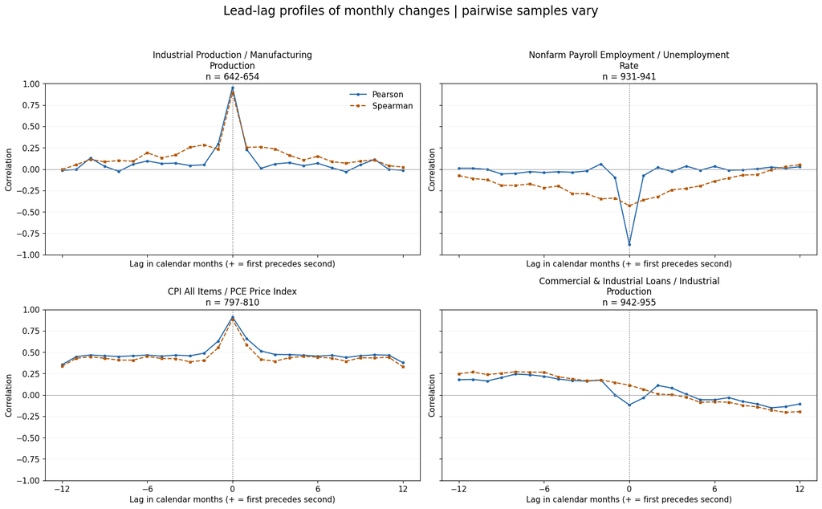

### Largest peak associations across the lag scan

Rows are the 20 pairs with the largest absolute peak Pearson coefficient over the scanned lags, including lag zero. This ranking is selected on the same data and is not predictive validation.

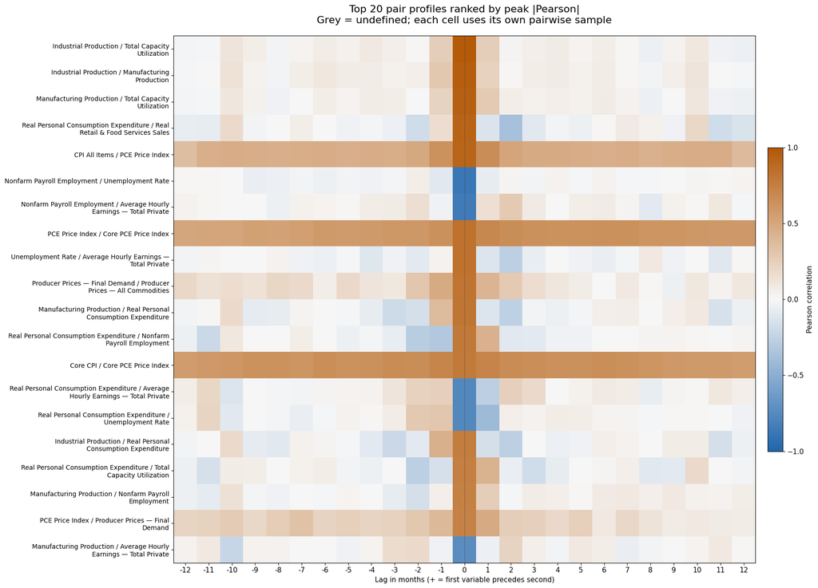

## Checks & Takeaways

- **Monthly series:** 27

- **Unique pairs:** 351

- **Lag range months:** -12 to +12

- **Pair lag evaluations:** 8775

- **Defined pearson coefficients:** 8775

- **Pairs with peak at zero:** 194

- **Pairs with peak away from zero:** 157

- **Evaluations below minimum overlap:** 0

- **Interpretation:** Nonzero peak lags are descriptive timing associations; multiple comparisons and release timing prevent predictive claims.

```
Input hashes verified unchanged. Exports: C:\Users\HYPE AMD\Desktop\CHronoZ-Economic-Modelling\outputs\lead_lag
```